# Assignment Clustering

##### Authors: Sergei Romanov (s.romanov@students.uu.nl)

# Step 1.

```r
library(dplyr)
library(tidyverse)
#install.packages('docstring')
#library(docstring)
clus_df <- read_csv("https://raw.githubusercontent.com/vankesteren/dav_practicals/master/12_Unsupervised_learning_Clustering/data/clusterdata.csv")
```

We added some docstrings in functions, which can help better understand the function. It is accssesible via **docstring(YOUR OBJECT)**, but we also kept our eye on the inline comments.

# Step 2. Euclidean distance

```r
l2_dist <- function(x, y) {
  #' @title Euclidean distance
  #' @description The function for Euclidean distance computation
  #' @param x -  An object of class "vector". Vector nf x-axis
  #' @param y - An object of class "vector". Vector nf x-axis
  #' @return Returns an object of class "double". Returns the Euclidean distance

  d = sqrt(sum((x - y)^2))
  return(d)
}
```

# Step 3. **K-medians clustering algorithm**

#### For this task we implemented Lloyd’s algorithm [1], for it is the most easy to make out of all k-means(medians) algorithms.

```r
kmedians <- function(df, k, iters=10) {
#' @title  K-median clustering
#' @description Function for k-medians clustering. The objects before the iterative part are
#' named in camelCase convention,
#' and after -- in snake_case, for the sake of convenience.
#' @param df -  An object of class "list". An Input data-frame
#' @param k - An object of class "double". Stands for the number of desired clusters
#' @param iters - An object of class "double". Stands for the number of desired iterations,
#' Default number is 10.
#' @return Clustering_vector - An object of class "double". The vector of clusters
#' @return Sum_of_distances - An object of class "list". The vector of clusters
#' @return Cluster_medians - An object of class "list". The vector of clusters
  #some conditions

  stopifnot(k <= nrow(df))

  centroids = sample.int(nrow(df),k) #Initialize random centroids
  centroidPoints = df[centroids,] %>% as.matrix()
  dataCoordinates = as.matrix(df)

  withinClusterSS <- c() # Initialize the vector for within-cluster sums of squared Eucledian

  for (m in 1:iters) {
    distances_matrix = matrix(0, nrow = nrow(dataCoordinates), ncol = k )
    for (j in 1:k) {
      for (i in 1:nrow(dataCoordinates)) {
        distances_matrix[i, j] = l2_dist(dataCoordinates[i,1:ncol(dataCoordinates)], centroidPoints[j,1:ncol(centroidPoints)])
      }
    }

  cluster = factor(apply(distances_matrix, 1, which.min)) # selects the minimum out of k columns
  distances_per_cluster <- list()
  for (i in 1:k) {
        distances_per_cluster[[i]] = distances_matrix[which(cluster == i, i)]^2
  }

  within_cluster_ss_temp <- unlist(lapply(distances_per_cluster, sum))
  withinClusterSS <- append(withinClusterSS, within_cluster_ss_temp)


  #Creates new centroids based on the within cluster medians
  new_centroid = as.data.frame(df) %>%
    cbind(Clusters = as.integer(cluster)) %>%
    group_by(Clusters) %>%
    summarise_all(median)

  centroidPoints = new_centroid[,-1] %>% as.matrix() #assign new centroids for new iteration
  }
  withinClusterSS <- t(array(withinClusterSS, dim = c(k, iters)))
  return(list(Clustering_vector = cluster,
              Sum_of_distances = withinClusterSS,
              Cluster_medians = centroidPoints))
}
```

# Step 4: Compare to K-means

1. First we graphically compare the stability of the clusters of kmeans and kmedians with two different random seeds.

Reflection: the plots provides that results are not so stable with K = 2, 4, 6, and results differ also between functions. Moreover, it is manifest that most probably the true k is equal to 3, as the out come is similar with both functions and both seeds. Overall, in all other cases clusters differ.

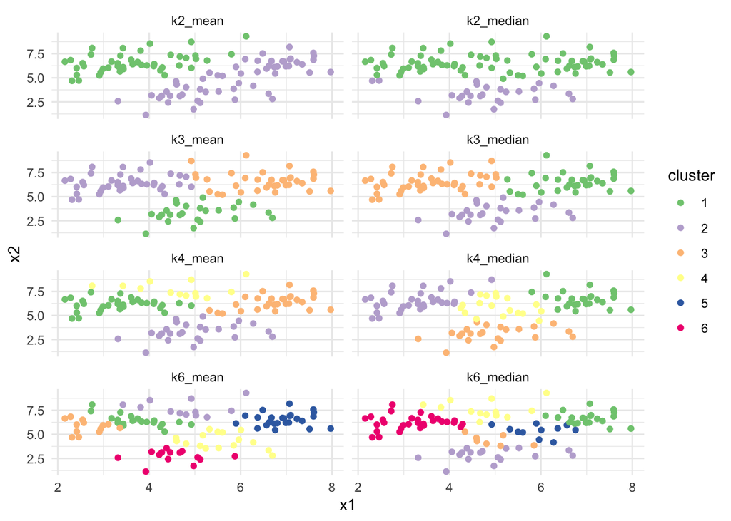

```r
# Set the seed for reproducibility
set.seed(45)

df_copy <- clus_df
df_copy %>%
  mutate(
    k2_median = as_factor(kmedians(df_copy, 2)$Clustering_vector),
    k3_median = as_factor(kmedians(df_copy, 3)$Clustering_vector),
    k4_median = as_factor(kmedians(df_copy, 4)$Clustering_vector),
    k6_median = as_factor(kmedians(df_copy, 6)$Clustering_vector),
    k2_mean = as_factor(kmeans(df_copy, 2)$cluster),
    k3_mean = as_factor(kmeans(df_copy, 3)$cluster),
    k4_mean = as_factor(kmeans(df_copy, 4)$cluster),
    k6_mean = as_factor(kmeans(df_copy, 6)$cluster),
  ) %>%
  pivot_longer(cols = c(k2_median, k3_median, k4_median, k6_median, k2_mean, k3_mean, k4_mean,k6_mean ),
               names_to = "class_num", values_to = "cluster") %>%
  ggplot(aes(x = x1, y = x2, colour = cluster)) +
  geom_point() +
  scale_colour_brewer(type = "qual") + # use easy to distinguish scale
  facet_wrap(~class_num, nrow = 4, ncol = 2, shrink = F) +
  theme_minimal()
```

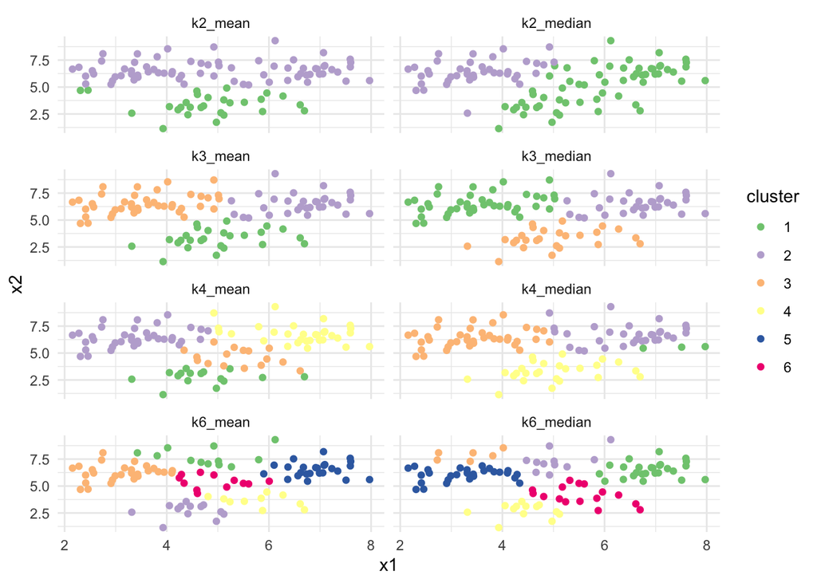

```r
# Set the seed for reproducibility
set.seed(46)
df_copy %>%
  mutate(
    k2_median = as_factor(kmedians(df_copy, 2)$Clustering_vector),
    k3_median = as_factor(kmedians(df_copy, 3)$Clustering_vector),
    k4_median = as_factor(kmedians(df_copy, 4)$Clustering_vector),
    k6_median = as_factor(kmedians(df_copy, 6)$Clustering_vector),
    k2_mean = as_factor(kmeans(df_copy, 2)$cluster),
    k3_mean = as_factor(kmeans(df_copy, 3)$cluster),
    k4_mean = as_factor(kmeans(df_copy, 4)$cluster),
    k6_mean = as_factor(kmeans(df_copy, 6)$cluster),
  ) %>%
  pivot_longer(cols = c(k2_median, k3_median, k4_median, k6_median, k2_mean, k3_mean, k4_mean,k6_mean ),
               names_to = "class_num", values_to = "cluster") %>%
  ggplot(aes(x = x1, y = x2, colour = cluster)) +
  geom_point() +
  scale_colour_brewer(type = "qual") + # use easy to distinguish scale
  facet_wrap(~class_num, nrow = 4, ncol = 2, shrink = F) +
  theme_minimal()
```

2. Then we check both with silhouette analysis.  
   Reflection: silhouette analysis resulted in no considerable difference.

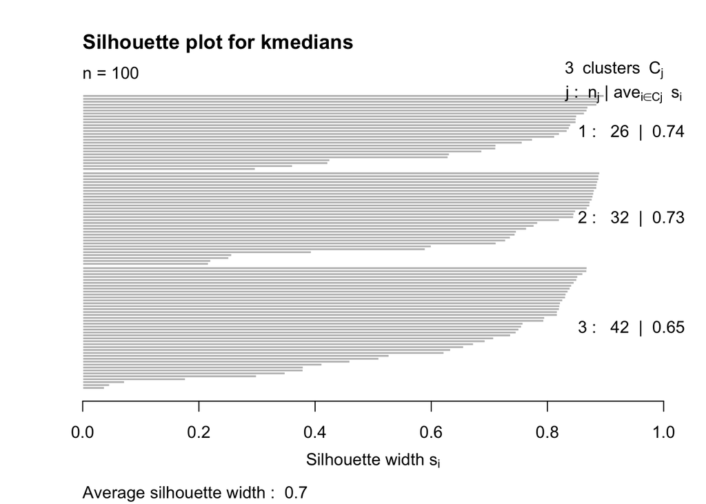

```r
#install.packages('cluster')
library(cluster)
dis = dist(clus_df)^2
res = kmedians(clus_df,3)
sil = silhouette(as.integer(res$Clustering_vector), dis)
plot(sil, main = 'Silhouette plot for kmedians' )
```

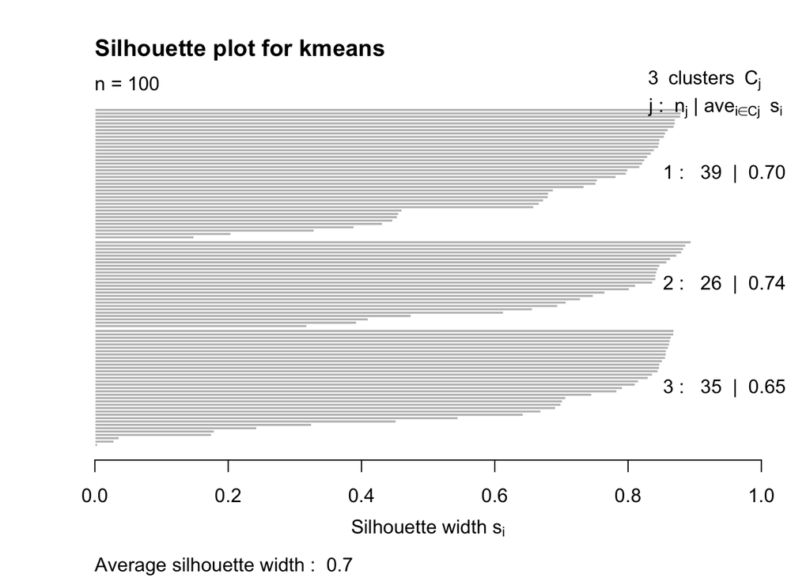

```r
dis = dist(clus_df)^2
res = kmeans(clus_df,3)
sil = silhouette (res$cluster, dis)
plot(sil, main = 'Silhouette plot for kmeans' )
```

Sources:  
1. Lloyd, S. (1982). Least squares quantization in PCM. IEEE transactions on information theory, 28(2), 129-137.  
2. https://danhdtruong.com/K-means-from-scratch-in-R/#k-means-clustering-algorithm  
3. https://datascience.stackexchange.com/questions/9858/convergence-in-hartigan-wong-k-means-method-and-other-algorithms?newreg=dbbcb10a6a6a4d289e0d7884256850d8